# Lab 8

# Back to the exercise

- take 10,000 random samples of length `n=100` from the `human_genes` dataset.
- first, create an object and insert the replicate function

```r
samp_reps<- replicate(

)
```

- define number of replicates:

```r
#let's test with 3 first
samp_reps<- replicate(n=3,
  simplify=TRUE) #simplify the output
```

# Insert the expression to be evaluated repeatedly

```r
#let's test with 3 first

samp_reps<- replicate(n=3, human_genes %>%
                        sample_n(size = 100, replace = F) %>%
                        select(size) %>%
                        pull()
                      )

#did it work?
class(samp_reps)
```

```
## [1] "matrix" "array"
```

```r
head(samp_reps)
```

```
##       [,1] [,2] [,3]
## [1,] 12041 7865 8711
## [2,]  2661  945 3218
## [3,]  4109 1345 3830
## [4,]  4517 1834 1526
## [5,]  6087 2448 2286
## [6,]  1724 1274 5818
```

# Calculate the summaries for each replicate sampled:

Make a function that calculates all the summaries

```r
my_summ<-function(x){
  mean_x<-mean(x) #mean
  median_x<-median(x) #median
  sd_x<-sd(x) #sd
  iqr_x<-IQR(x) #iqr
  mode<-sort(x,decreasing = T)[1] #mode
  SEM<-sd_x/sqrt(length(x)) #standard error from one resamp
  return(list(Mean=mean_x, Median=median_x, SD=sd_x, IQR=iqr_x, Mode=mode, SEM=SEM))
}

#test
my_summ(x=samp_reps[,1])
```

```
## $Mean
## [1] 4182.55
##
## $Median
## [1] 3209
##
## $SD
## [1] 3241.214
##
## $IQR
## [1] 3431
##
## $Mode
## [1] 18277
##
## $SEM
## [1] 324.1214
```

# Calculate the summaries for each replicate sampled:

Use your function on all the replicates.

Option 1: Using the `apply` function:

```r
#how apply works

#X: data, MARGIN: 1 for rows, 2 for columns
#FUN for function
apply(X=matrix(c(1,2,3,4,5,6), ncol=2), MARGIN=2, FUN=function(x) mean(x))
```

```
## [1] 2 5
```

# Calculate the summaries for each replicate sampled:

Use your function on all the replicates.

Option 1: Using the `apply` function:

```r
#retain only the mean
just_means<-apply(X=samp_reps, 2, function(x) my_summ(x)$Mean)

#make a data.frame

just_means_dt<-data.frame(Mean=just_means, Rep=1:3)
```

# Plot a distribution of the means

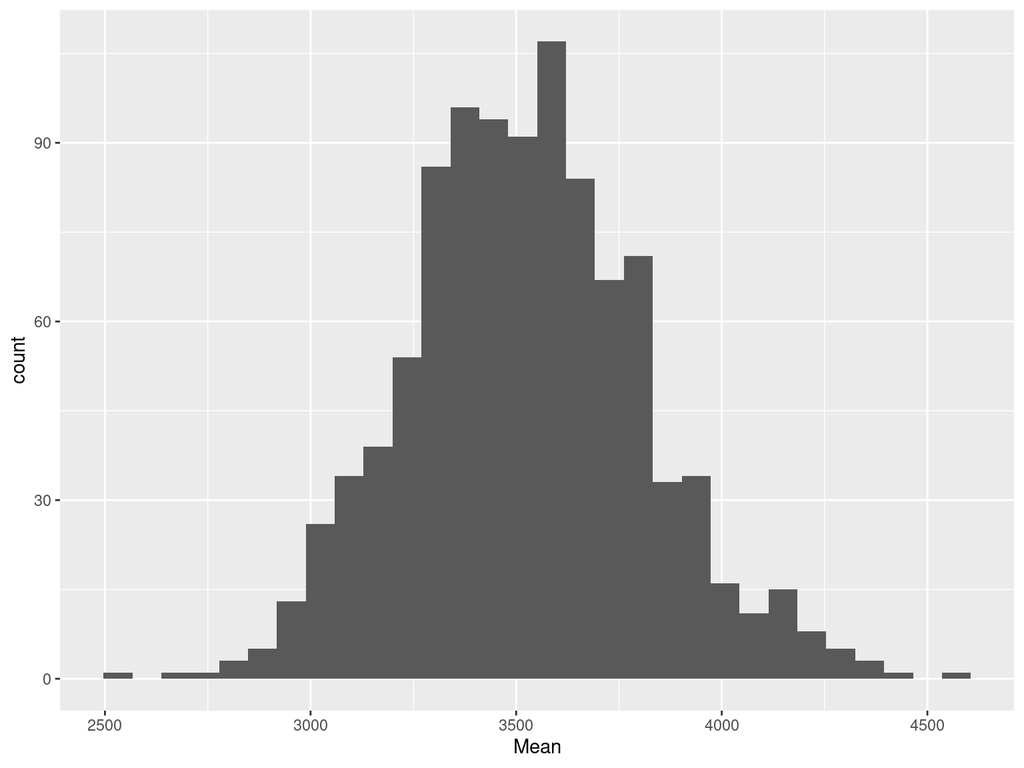

```r
#first, make more replicates to get a proper distribution
samp_reps<- replicate(n=1000, human_genes %>%
                        sample_n(size = 100, replace = F) %>%
                        select(size) %>%
                        pull()
                      )
#retain only the mean
just_means<-apply(X=samp_reps, 2, function(x) my_summ(x)$Mean)
#make a data.frame
just_means_dt<-data.frame(Mean=just_means, Rep=1:1000)
#plot
ggplot(just_means_dt, aes(Mean)) +
  geom_histogram()
```

# Explore the sampling distribution

- calculate the standard deviation of the sampling distribution and compare it to the standard error you obtain by applying the standard formula $\sigma_{\bar X}=\frac{\sigma_{X}}{\sqrt{n}}$. *They are SUPER similar!*

```r
#SD of the sampling distribution
#the GRAND MEAN
mean(just_means_dt$Mean)
```

```
## [1] 3523.524
```

```r
sd(just_means_dt$Mean)
```

```
## [1] 286.6783
```

```r
#standard formula
sd(human_genes$size)/sqrt(100)
```

```
## [1] 283.3293
```

# Oof!

Congratulations! You learned:

*conditional statements (if/else)* apply *replicate (tidyverse version of apply)